# Distribution shifts in predictive panels

# 1 Packages

First, we load the required packages.

```r
if(!require(tidyverse)){install.packages(c("tidyverse", "lubridate", "nlshrink", "broom", "gt"))}
library(tidyverse)  # Data handling
library(lubridate)  # Date handling
library(nlshrink)   # Shrinkage estimators
library(broom)      # Regression output
library(latex2exp)  # LaTeX in ggplot
library(gt)         # Neat tables
```

# 2 Data

Second, we download & format the data.  
**NOTE**: depending on the files, the number of rows to skip changes. It typically varies between 2 and 10.

```r
temp <- tempfile()
link <- "http://mba.tuck.dartmouth.edu/pages/faculty/ken.french/ftp/10_Industry_Portfolios_daily_CSV.zip"

download.file(link, temp, quiet = TRUE)                       # Download!
df_assets <- read_csv(unz(temp, "10_Industry_Portfolios_Daily.CSV"),  skip = 9) %>%
    # Check the nb of lines to skip
    rename(Date = X1) %>%                                     # Change name of the first column
    mutate_at(vars(-Date), as.numeric) %>%                    # Convert to number
    mutate(Date = ymd(parse_date_time(Date, "%Y%m%d")))       # End of month date
split <- which(is.na(df_assets$Date))[1]                      # Split between portfolio types!
df_assets <- df_assets[1:(split-1),]
df_assets <- df_assets %>% filter(year(Date) >= 1955)         # Before 1955: a bit messy

colnames(df_assets)[1] <- "date"
stock_ids <- colnames(df_assets[,c(2:ncol(df_assets))])       # List of assets
nb_assets <- length(stock_ids)                                # Number of assets
list_years <- c(1980:2021)                                    # List of years considered
```

# 3 Main function

Note: it allows for sample versus shrinkage estimators (see last argument of the function).

```r
time_series_output <- function(nb_assets, df_assets, sample_size, shrinkage){ # The main function

    one_n <- as.matrix(rep(1,nb_assets))            # A vector of ones
    nb_dates <- length(df_assets$date)              # The number of dates
    list_daily_dates <- df_assets$date              # List of these dates

    Sigma_is <- list()                              # Initializing the variables
    Sigma_oos <- list()
    inv_Sigma_is <- list()
    inv_Sigma_oos <- list()
    vec_mu_is <- list()
    vec_mu_oos <- list()

    nb_t <- sample_size * 21                        # Or: 500 # 252 # Length of samples (is & oos)
    t0 <- nb_t                                      # start date
    step_lgth <- 21

    nb_points <- (nb_dates - 2*nb_t) %/% step_lgth  # Max number of monthly steps in the dataset
    tend <- t0 + step_lgth*nb_points
    one_t <- as.matrix(rep(1,nb_t))
    date_list <- as.Date(df_assets[t0+nb_t,]$date)

    for(j in 1:nb_points){
        n_start_is <- t0+(j-1)*step_lgth - nb_t + 1
        n_end_is <- t0+(j-1)*step_lgth
        n_start_oos <- t0+(j-1)*step_lgth + 1       # Out-of-sample starts the day after
        n_end_oos <- t0+(j-1)*step_lgth + nb_t
        date_list[j] <- as.Date(df_assets[n_end_is,]$date)

        # In-sample
        data_temp_is <- df_assets[c(n_start_is:n_end_is),]
        if(shrinkage == TRUE){
            Sigma_is[[j]] <- linshrink_cov(X = as.matrix(data_temp_is[stock_ids]))
        } else {
            Sigma_is[[j]] <- var(data_temp_is[stock_ids])                 # Sigma_is = X'X
        }
        vec_mu_is[[j]] <- as.matrix(colMeans(data_temp_is[stock_ids]))    # v_is = X'y
        inv_Sigma_is[[j]] <- solve(Sigma_is[[j]])                         # Sigma_is^{-1}

        # Out-of-Sample
        data_temp_oos <- df_assets[c(n_start_oos:n_end_oos),]
        if(shrinkage == TRUE){
            Sigma_oos[[j]] <- linshrink_cov(X = as.matrix(data_temp_oos[stock_ids]))
        } else {
            Sigma_oos[[j]] <- var(data_temp_oos[stock_ids])
        }
        vec_mu_oos[[j]] <- as.matrix(colMeans(data_temp_oos[stock_ids]))
        inv_Sigma_oos[[j]] <- solve(Sigma_oos[[j]])

    }

    loss_series <- 0 # SSR
    dt_series <- 0
    Deltat_series <- 0

    for(j in 1:nb_points){
        loss_series[j] <- t(vec_mu_is[[j]]) %*% inv_Sigma_is[[j]] %*% Sigma_oos[[j]] %*% inv_Sigma_is[[j]] %*% vec_mu_is[[j]] -
            2 * t(vec_mu_is[[j]]) %*% inv_Sigma_is[[j]] %*% vec_mu_oos[[j]] +
            t(vec_mu_oos[[j]]) %*% inv_Sigma_oos[[j]] %*% vec_mu_oos[[j]]
        Deltat_series[j] <- 0.00001*norm(inv_Sigma_is[[j]] - inv_Sigma_oos[[j]], type = "2")  # Covariate shift
        dt_series[j] <- 10*sum(abs(vec_mu_is[[j]] - vec_mu_oos[[j]]))                         # Concept drift
    }

    output <- list(date_list = date_list, L = loss_series, d_t = dt_series, Delta_t = Deltat_series)
    return(output)
} # End of function
```

Then, we gather the estimates for the loss $L$, the drift $d_t$ and the shift $D_t$.

```r
shrink_k <- TRUE

fct_output1m <- time_series_output(nb_assets, df_assets, 1, shrink_k)
output1m <- data.frame(date = fct_output1m$date_list, L = fct_output1m$L, d_t = fct_output1m$d_t, D_t = fct_output1m$Delta_t)
fct_output3m <- time_series_output(nb_assets, df_assets, 3, shrink_k)
output3m <- data.frame(date = fct_output3m$date_list, L = fct_output3m$L, d_t = fct_output3m$d_t, D_t = fct_output3m$Delta_t)
fct_output6m <- time_series_output(nb_assets, df_assets, 6, shrink_k)
output6m <- data.frame(date = fct_output6m$date_list, L = fct_output6m$L, d_t = fct_output6m$d_t, D_t = fct_output6m$Delta_t)
```

# 4 Graph

Finally, we plot the results.

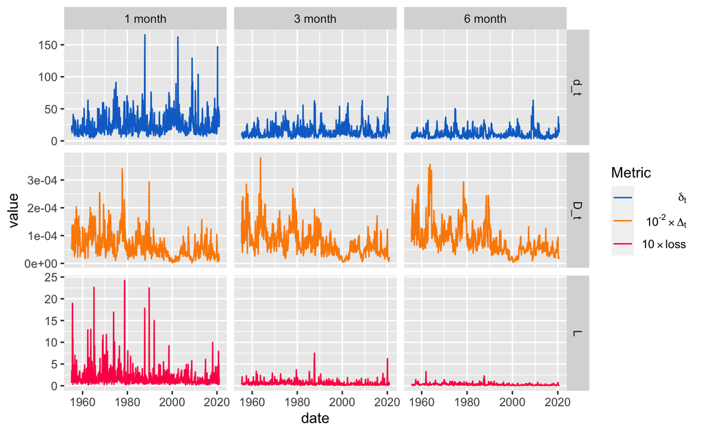

```r
bind_rows(bind_cols(output1m, sample ="1 month"),
          bind_cols(output3m, sample ="3 month"),
          bind_cols(output6m, sample ="6 month")) %>%
    pivot_longer(-c(date, sample), names_to = "indicator", values_to = "value") %>%
    ggplot(aes(x = date, y = value, color = indicator)) + geom_line() +
    facet_grid(indicator~sample, scales = "free") +
    scale_color_manual(values = c("#0D70CD", "#FC8B02", "#FC0255"),
                       labels = unname(TeX(c("$\\delta_t$", "$10^{-2} \\times\\Delta_t$", "$10\\times loss$"))), name = "Metric")
```

# 5 Regression analysis

Regression analysis: Loss in terms of SSR Regressed against covariate shift and concept drift, both squared + cross term.

## 5.1 One month samples

First, the dataset where all is stored. We start with one month samples for the estimators.

```r
data_reg1m <- data.frame(date = fct_output1m$date_list,
                         D_t2 = (fct_output1m$Delta_t*100)^2,           # Scaled
                         d_t2 = (fct_output1m$d_t)^2,
                         D_t_dt = fct_output1m$Delta_t*fct_output1m$d_t,
                         D_t = fct_output1m$Delta_t,
                         d_t = fct_output1m$d_t,
                         loss = fct_output1m$L)
```

Next, regressions! The output is shown in format table below.

```r
m1_all <- lm(loss ~ D_t2 + d_t2 + D_t_dt, data_reg1m) %>%
    tidy() %>% bind_cols(sample = "ALL")
m1_1980 <- lm(loss ~ D_t2 + d_t2 + D_t_dt,
              data_reg1m %>% dplyr::filter(date < "1990-01-01")) %>%
    tidy() %>% bind_cols(sample = "1980s")
m1_1990 <- lm(loss ~ D_t2 + d_t2 + D_t_dt,
              data_reg1m %>% dplyr::filter(date < "2000-01-01", date >= "1990-01-01")) %>%
    tidy() %>% bind_cols(sample = "1990s")
m1_2000 <- lm(loss ~ D_t2 + d_t2 + D_t_dt,
              data_reg1m %>% dplyr::filter(date < "2010-01-01", date >= "2000-01-01")) %>%
    tidy() %>% bind_cols(sample = "2000s")
m1_2010 <- lm(loss ~ D_t2 + d_t2 + D_t_dt,
              data_reg1m %>% dplyr::filter(date >= "2010-01-01")) %>%
    tidy() %>% bind_cols(sample = "2010s")
```

## 5.2 Three month samples

Then, 3 months samples.

```r
data_reg3m <- data.frame(date = fct_output3m$date_list,
                         D_t2 = (fct_output3m$Delta_t*100)^2,             # Scaled
                         d_t2 = (fct_output3m$d_t)^2,
                         D_t_dt = fct_output3m$Delta_t*fct_output3m$d_t,
                         D_t = fct_output3m$Delta_t,
                         d_t = fct_output3m$d_t,
                         loss = fct_output3m$L)
m3_all <- lm(loss ~ D_t2 + d_t2 + D_t_dt, data_reg3m) %>%
    tidy() %>% bind_cols(sample = "ALL")
m3_1980 <- lm(loss ~ D_t2 + d_t2 + D_t_dt,
              data_reg3m %>% dplyr::filter(date < "1990-01-01")) %>%
    tidy() %>% bind_cols(sample = "1980s")
m3_1990 <- lm(loss ~ D_t2 + d_t2 + D_t_dt,
              data_reg3m %>% dplyr::filter(date < "2000-01-01", date >= "1990-01-01")) %>%
    tidy() %>% bind_cols(sample = "1990s")
m3_2000 <- lm(loss ~ D_t2 + d_t2 + D_t_dt,
              data_reg3m %>% dplyr::filter(date < "2010-01-01", date >= "2000-01-01")) %>%
    tidy() %>% bind_cols(sample = "2000s")
m3_2010 <- lm(loss ~ D_t2 + d_t2 + D_t_dt,
              data_reg3m %>% dplyr::filter(date >= "2010-01-01")) %>%
    tidy() %>% bind_cols(sample = "2010s")
```

## 5.3 Six month samples

Finally, the 6 month samples

```r
data_reg6m <- data.frame(date = fct_output6m$date_list,
                         D_t2 = (fct_output6m$Delta_t*100)^2,            # Scaled
                         d_t2 = (fct_output6m$d_t)^2,
                         D_t_dt = fct_output6m$Delta_t*fct_output6m$d_t,
                         D_t = fct_output6m$Delta_t,
                         d_t = fct_output6m$d_t,
                         loss = fct_output6m$L)

m6_all <- lm(loss ~ D_t2 + d_t2 + D_t_dt, data_reg6m) %>%
    tidy() %>% bind_cols(sample = "ALL")
m6_1980 <- lm(loss ~ D_t2 + d_t2 + D_t_dt,
              data_reg6m %>% dplyr::filter(date < "1990-01-01")) %>%
    tidy() %>% bind_cols(sample = "1980s")
m6_1990 <- lm(loss ~ D_t2 + d_t2 + D_t_dt,
              data_reg6m %>% dplyr::filter(date < "2000-01-01", date >= "1990-01-01")) %>%
    tidy() %>% bind_cols(sample = "1990s")
m6_2000 <- lm(loss ~ D_t2 + d_t2 + D_t_dt,
              data_reg6m %>% dplyr::filter(date < "2010-01-01", date >= "2000-01-01")) %>%
    tidy() %>% bind_cols(sample = "2000s")
m6_2010 <- lm(loss ~ D_t2 + d_t2 + D_t_dt,
              data_reg6m %>% dplyr::filter(date >= "2010-01-01")) %>%
    tidy() %>% bind_cols(sample = "2010s")
```

## 5.4 The table

The long code for the table is located below.  
The *p*-value are coded in colors: the redder the lower.  
For the *t*-statistics, the ones that have an absolute value larger than 3 are highlighted in blue.  
We use a threshold of three following the conclusions of Harvey et al (2016) *… and the cross-section of expected return*.  
Only one is negative: it is the one for which one other variable is highly and significantly positive.

| term | 1 month sample Estimate | 1 month sample Std. Err. | 1 month sample t-stat | 1 month sample p-val | 3 month sample Estimate | 3 month sample Std. Err. | 3 month sample t-stat | 3 month sample p-val | 6 month sample Estimate | 6 month sample Std. Err. | 6 month sample t-stat | 6 month sample p-val |
| --- | --- | --- | --- | --- | --- | --- | --- | --- | --- | --- | --- | --- |
| ALL |  |  |  |  |  |  |  |  |  |  |  |  |
| (Intercept) | 0.833 | 0.116 | 7.184 | 0.000 | 0.236 | 0.027 | 8.883 | 0.000 | 0.149 | 0.012 | 12.479 | 0.000 |
| D_t2 | 1440.206 | 976.515 | 1.475 | 0.141 | −485.733 | 204.010 | −2.381 | 0.018 | −184.477 | 60.841 | −3.032 | 0.003 |
| d_t2 | 0.000 | 0.000 | 0.930 | 0.353 | −0.000 | 0.000 | −0.213 | 0.831 | −0.000 | 0.000 | −1.942 | 0.053 |
| D_t_dt | 618.350 | 73.760 | 8.383 | 0.000 | 399.960 | 26.825 | 14.910 | 0.000 | 214.280 | 13.373 | 16.023 | 0.000 |
| 1980s |  |  |  |  |  |  |  |  |  |  |  |  |
| (Intercept) | 0.893 | 0.215 | 4.147 | 0.000 | 0.268 | 0.044 | 6.052 | 0.000 | 0.198 | 0.024 | 8.377 | 0.000 |
| D_t2 | 1776.997 | 1310.045 | 1.356 | 0.176 | −486.938 | 255.878 | −1.903 | 0.058 | −222.774 | 82.396 | −2.704 | 0.007 |
| d_t2 | 0.000 | 0.000 | 1.145 | 0.253 | −0.000 | 0.000 | −0.183 | 0.855 | −0.000 | 0.000 | −0.710 | 0.478 |
| D_t_dt | 573.421 | 111.071 | 5.163 | 0.000 | 384.254 | 40.805 | 9.417 | 0.000 | 195.779 | 21.561 | 9.080 | 0.000 |
| 1990s |  |  |  |  |  |  |  |  |  |  |  |  |
| (Intercept) | 0.410 | 0.241 | 1.704 | 0.091 | 0.338 | 0.051 | 6.591 | 0.000 | 0.119 | 0.029 | 4.085 | 0.000 |
| D_t2 | −11178.117 | 8780.148 | −1.273 | 0.206 | −827.994 | 1661.962 | −0.498 | 0.619 | −829.000 | 825.444 | −1.004 | 0.317 |
| d_t2 | −0.000 | 0.000 | −0.082 | 0.935 | 0.000 | 0.000 | 0.489 | 0.626 | 0.000 | 0.000 | 0.922 | 0.358 |
| D_t_dt | 1491.931 | 349.160 | 4.273 | 0.000 | 318.282 | 98.523 | 3.231 | 0.002 | 325.115 | 97.442 | 3.337 | 0.001 |
| 2000s |  |  |  |  |  |  |  |  |  |  |  |  |
| (Intercept) | 0.852 | 0.159 | 5.363 | 0.000 | 0.086 | 0.049 | 1.763 | 0.080 | 0.147 | 0.019 | 7.930 | 0.000 |
| D_t2 | 2064.373 | 5036.202 | 0.410 | 0.683 | 1043.288 | 1368.616 | 0.762 | 0.447 | 1062.572 | 647.894 | 1.640 | 0.104 |
| d_t2 | 0.000 | 0.000 | 1.132 | 0.260 | 0.000 | 0.000 | 1.954 | 0.053 | 0.000 | 0.000 | 0.909 | 0.365 |
| D_t_dt | 591.297 | 222.562 | 2.657 | 0.009 | 439.691 | 107.947 | 4.073 | 0.000 | 13.940 | 47.162 | 0.296 | 0.768 |
| 2010s |  |  |  |  |  |  |  |  |  |  |  |  |
| (Intercept) | 1.025 | 0.171 | 5.988 | 0.000 | 0.145 | 0.076 | 1.915 | 0.058 | 0.063 | 0.016 | 3.934 | 0.000 |
| D_t2 | −4928.256 | 3572.465 | −1.380 | 0.170 | −2047.488 | 1611.014 | −1.271 | 0.206 | −105.125 | 451.120 | −0.233 | 0.816 |
| d_t2 | −0.000 | 0.000 | −1.054 | 0.294 | −0.000 | 0.000 | −1.404 | 0.163 | −0.000 | 0.000 | −2.433 | 0.016 |
| D_t_dt | 454.046 | 156.665 | 2.898 | 0.004 | 635.391 | 114.119 | 5.568 | 0.000 | 318.070 | 43.395 | 7.330 | 0.000 |

The code for the table (using the **gt** package):

```r
bind_cols(
    bind_rows(m1_all, m1_1980, m1_1990, m1_2000, m1_2010),
    bind_rows(m3_all, m3_1980, m3_1990, m3_2000, m3_2010) %>% select(-term, -sample),
    bind_rows(m6_all, m6_1980, m6_1990, m6_2000, m6_2010) %>% select(-term, -sample)
) %>%
    group_by(sample) %>%
    gt() %>%
    cols_label(
    `estimate...2` = "Estimate",
    `estimate...7` = "Estimate",
    `estimate...11` = "Estimate",
    `std.error...3` = "Std. Err.",
    `std.error...8` = "Std. Err.",
    `std.error...12` = "Std. Err.",
    `statistic...4` = "t-stat",
    `statistic...9` = "t-stat",
    `statistic...13` = "t-stat",
    `p.value...5` = "p-val",
    `p.value...10` = "p-val",
    `p.value...14` = "p-val"
  ) %>%
    tab_spanner(
        label = "1 month sample",
        columns = 2:5
    ) %>%
    tab_spanner(
        label = "3 month sample",
        columns = 7:10
    ) %>%
    tab_spanner(
        label = "6 month sample",
        columns = 11:14
    ) %>%
    fmt_number(
        columns = 2:14,
        decimals = 3,
        use_seps = FALSE
    )  %>%
    tab_style(
        style = list(
            cell_fill(color = "#DDDDDD"),
            cell_text(weight = "bold")
        ),
        locations = cells_row_groups()
    ) %>%
    data_color(
        columns = c("p.value...5","p.value...10", "p.value...14"),
        colors = scales::col_numeric(
            palette = c(
                "#FE756A", "#FFF97B"),
            domain = c(0, 1),
            alpha = 0.5)
    ) %>%
    tab_style(
    style = list(
      cell_fill(color = "#A2BAE4"),
      cell_text(style = "italic")
      ),
    locations = cells_body(
      columns = "statistic...4",
      rows = abs(`statistic...4`) > 3
    )
  ) %>%
    tab_style(
    style = list(
      cell_fill(color = "#A2BAE4"),
      cell_text(style = "italic")
      ),
    locations = cells_body(
      columns = "statistic...9",
      rows = abs(`statistic...9`) > 3
    )
  )  %>%
    tab_style(
    style = list(
      cell_fill(color = "#A2BAE4"),
      cell_text(style = "italic")
      ),
    locations = cells_body(
      columns = "statistic...13",
      rows = abs(`statistic...13`) > 3
    )
  )
```